# Package demo

```
## [1] "Etude des modeles de prediction de: PV"
```

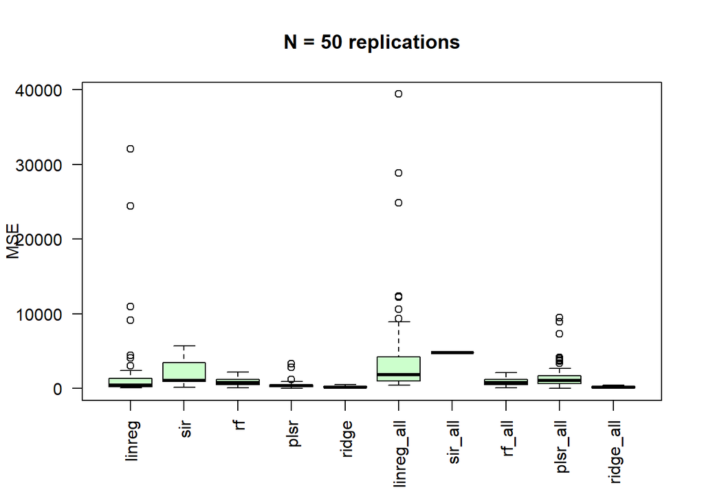

```
## [1] "choix methode: ridge"
```

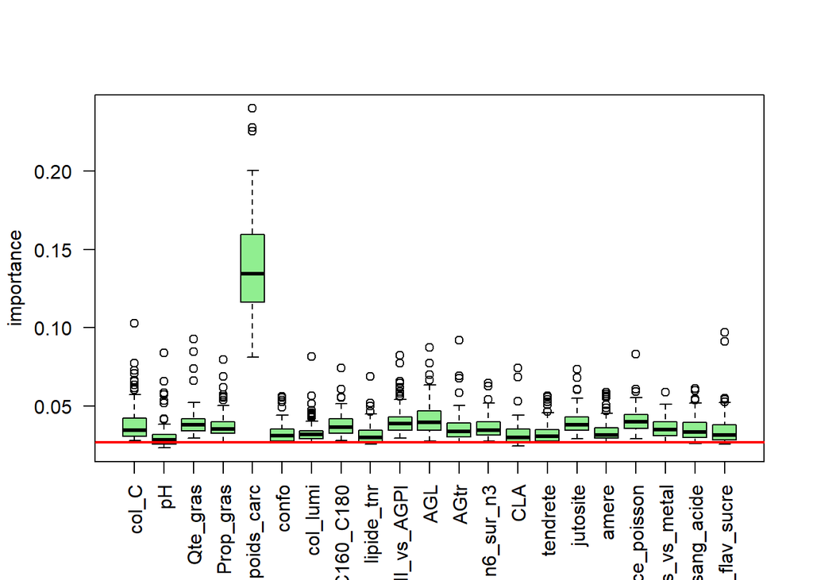

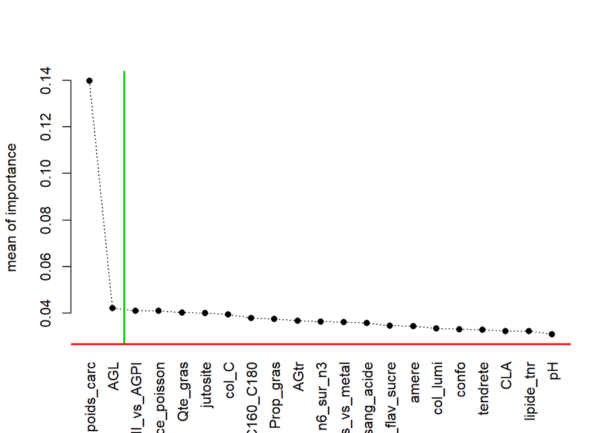

```
##            Length Class  Mode
## lambda     99     -none- numeric
## cvm        99     -none- numeric
## cvsd       99     -none- numeric
## cvup       99     -none- numeric
## cvlo       99     -none- numeric
## nzero      99     -none- numeric
## name        1     -none- character
## glmnet.fit 12     elnet  list
## lambda.min  1     -none- numeric
## lambda.1se  1     -none- numeric
## Xlabels     2     -none- character
## Ylabel      1     -none- character
## y_train    30     -none- numeric
## x_train    60     -none- numeric
## [1] "Etude des modeles de prediction de: GMQ"
```

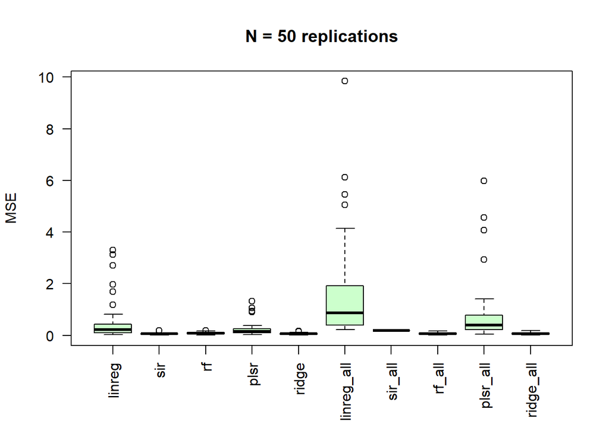

```
## [1] "choix methode: ridge"
```

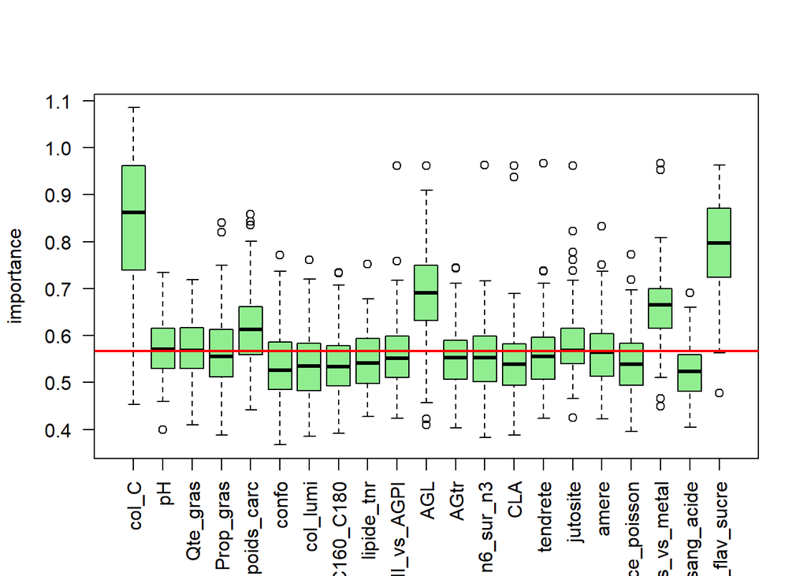

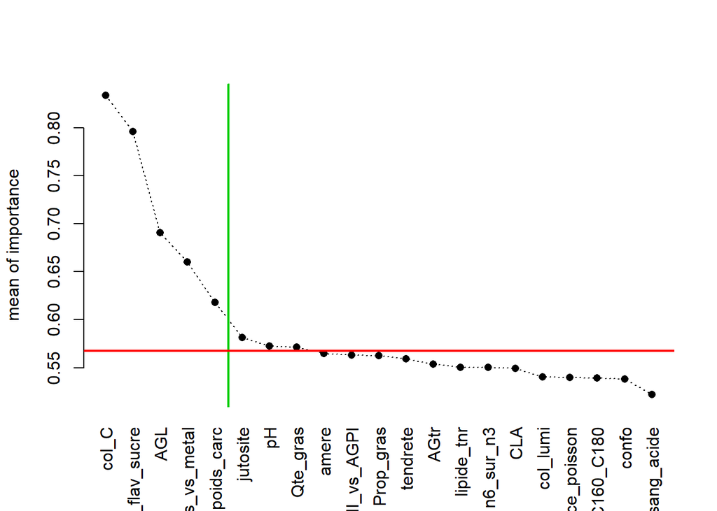

```
##            Length Class  Mode
## lambda      98    -none- numeric
## cvm         98    -none- numeric
## cvsd        98    -none- numeric
## cvup        98    -none- numeric
## cvlo        98    -none- numeric
## nzero       98    -none- numeric
## name         1    -none- character
## glmnet.fit  12    elnet  list
## lambda.min   1    -none- numeric
## lambda.1se   1    -none- numeric
## Xlabels      5    -none- character
## Ylabel       1    -none- character
## y_train     30    -none- numeric
## x_train    150    -none- numeric
## [1] "Etude des modeles de prediction de: Eff_alim"
```

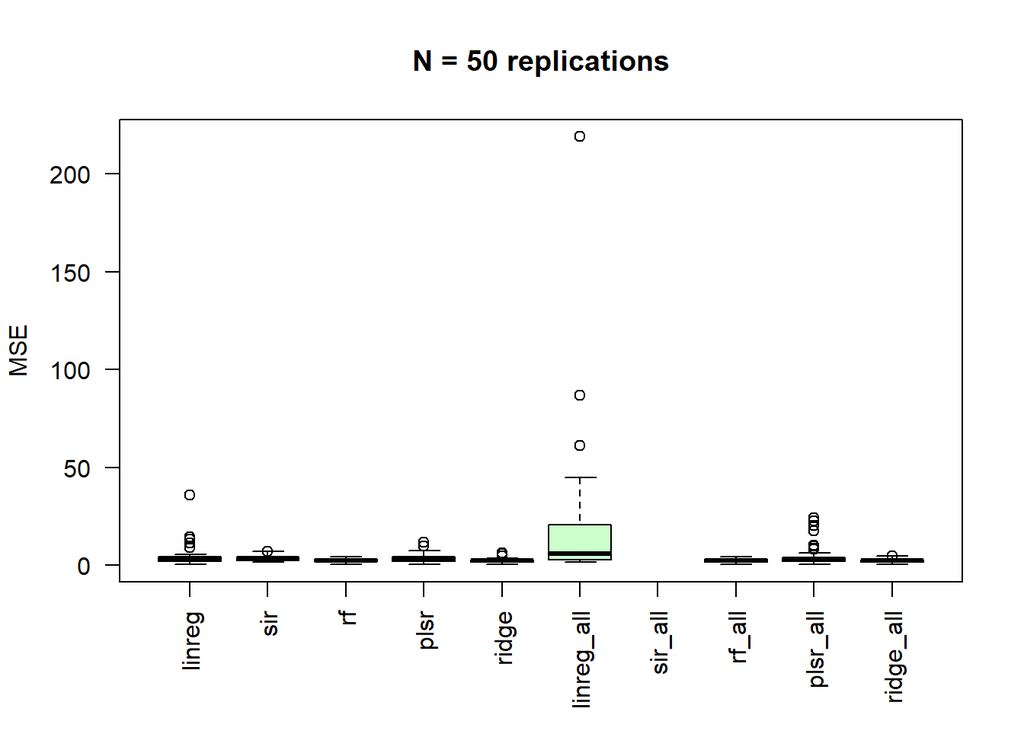

```
## [1] "choix methode: ridge"
```

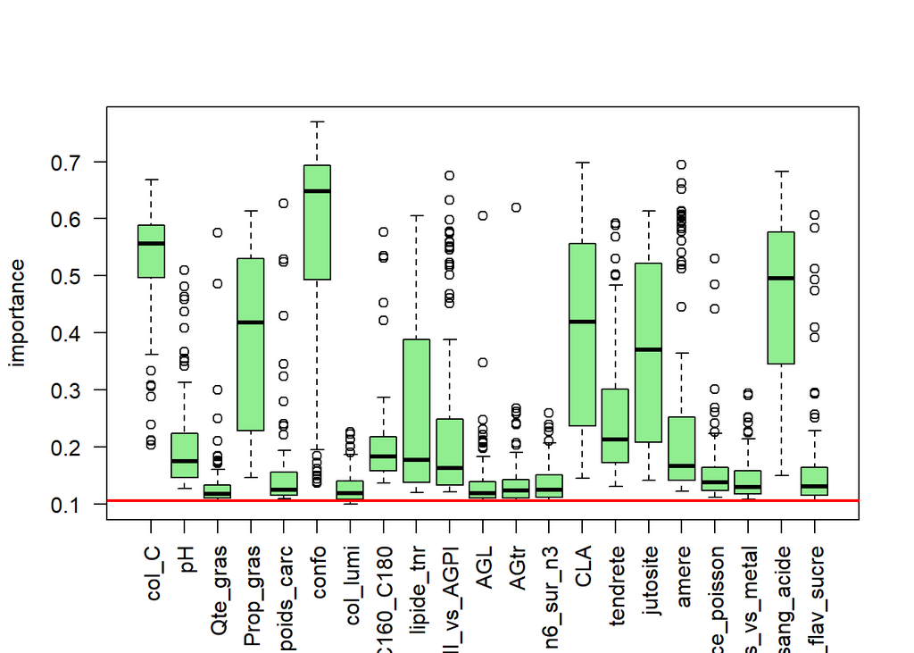

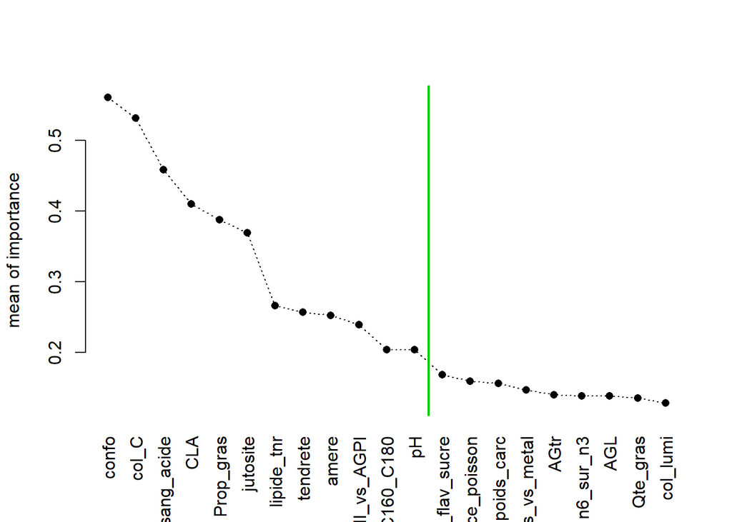

```
##            Length Class  Mode
## lambda      99    -none- numeric
## cvm         99    -none- numeric
## cvsd        99    -none- numeric
## cvup        99    -none- numeric
## cvlo        99    -none- numeric
## nzero       99    -none- numeric
## name         1    -none- character
## glmnet.fit  12    elnet  list
## lambda.min   1    -none- numeric
## lambda.1se   1    -none- numeric
## Xlabels     12    -none- character
## Ylabel       1    -none- character
## y_train     30    -none- numeric
## x_train    360    -none- numeric
## [1] "Etude des modeles de prediction de: col_C"
```

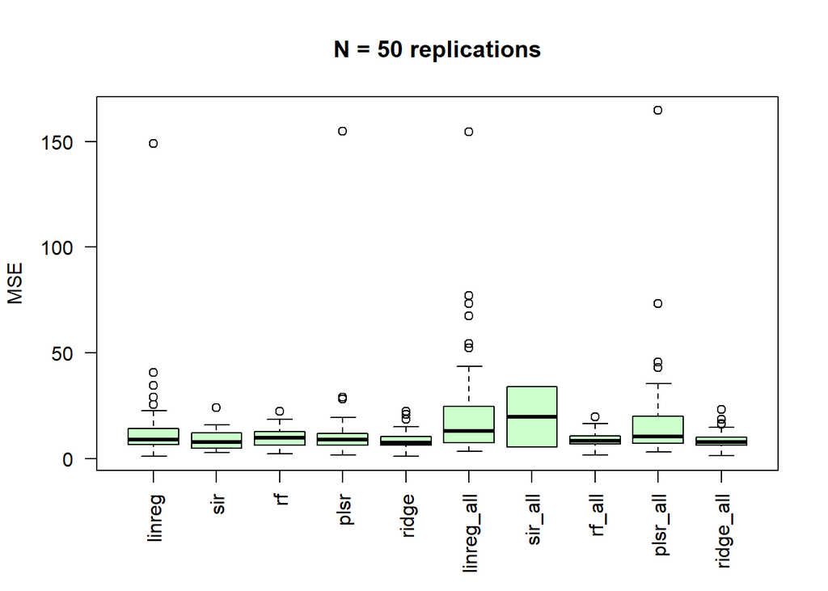

```
## [1] "choix methode: ridge"
```

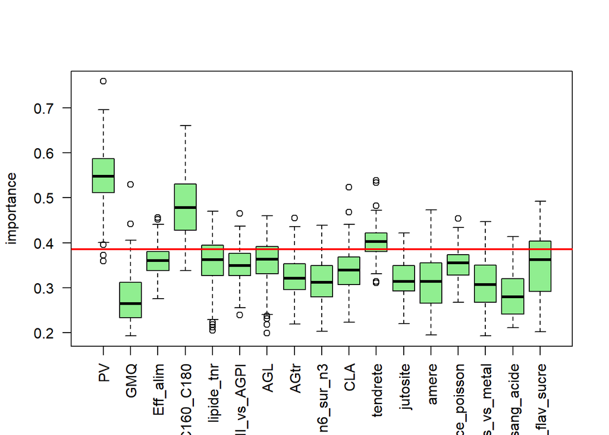

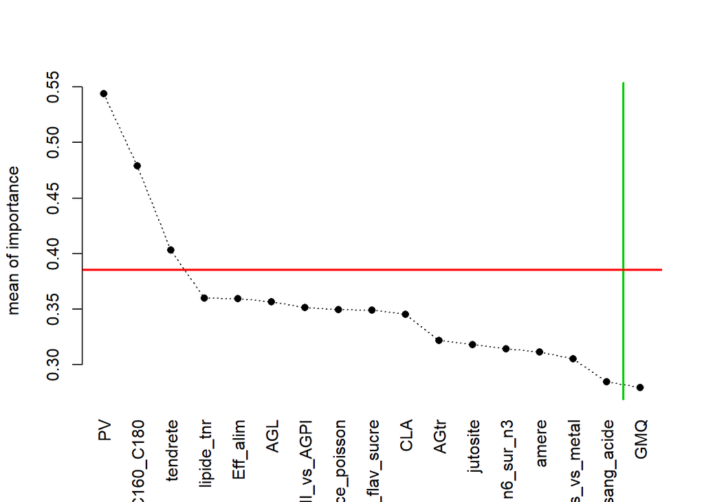

```
##            Length Class  Mode
## lambda      98    -none- numeric
## cvm         98    -none- numeric
## cvsd        98    -none- numeric
## cvup        98    -none- numeric
## cvlo        98    -none- numeric
## nzero       98    -none- numeric
## name         1    -none- character
## glmnet.fit  12    elnet  list
## lambda.min   1    -none- numeric
## lambda.1se   1    -none- numeric
## Xlabels     16    -none- character
## Ylabel       1    -none- character
## y_train     30    -none- numeric
## x_train    480    -none- numeric
## [1] "Etude des modeles de prediction de: pH"
```

[62 more figures not shown]

```r
#select and save the model in a list
set.seed(123)
load('../data/choiceModelsFinal.RData')
models <- list()

for (i in 1:24){
  #load modeles
  Ylabel <- colnames(data)[i]
  print(paste('Etude des modeles de prediction de:', Ylabel, sep = ' '))
  head(choiceModels[[i]]$mse)
  head(choiceModels[[i]]$mse_all)
  head(choiceModels[[i]]$r2)

  #selection of the best model on the R2
  perf_moy <- apply(X = choiceModels[[i]]$mse, MARGIN = 2, FUN = mean, na.rm = TRUE)
  sel_model <-  which(perf_moy == min(perf_moy))

  #plot the best method ----
  #RMSE
  boxplot(choiceModels[[i]], method = c("linreg", "sir", 'rf', "plsr", "ridge"),
          type = "both", col = rgb(0,1,0,0.2), las = 2,
          main = "N = 50 replications")



  ######plot the variables selected for each model ----
  ##linreg
  #varaible selected
  # barplot(choiceModels[[i]], method="linreg", type="varsel", las = 2,
  #         main = "linreg", col = rgb(1,1,0,0.2))

  #total use of each variable in all the simulation
  # barplot(choiceModels[[i]], method="linreg", type="sizemod", las = 2,
  #         main = "linreg", col = rgb(0,1,1,0.2))

  ##sir
  #varaible selected
  # barplot(choiceModels[[i]], method="sir", type="varsel", las = 2,
  #         main = "sir", col = rgb(1,1,0,0.2))

  #total use of each variable in all the simulation
  # barplot(choiceModels[[i]], method="sir", type="sizemod", las = 2,
  #         main = "sir", col = rgb(0,1,1,0.2))

  ##rf
  #varaible selected
  # barplot(choiceModels[[i]], method="rf", type="varsel", las = 2,
  #         main = "rf", col = rgb(1,1,0,0.2))

  #total use of each variable in all the simulation
  # barplot(choiceModels[[i]], method="rf", type="sizemod", las = 2,
  #         main = "rf", col = rgb(0,1,1,0.2))

  ##plsr
  #varaible selected
  # barplot(choiceModels[[i]], method="plsr", type="varsel", las = 2,
  #         main = "plsr", col = rgb(1,1,0,0.2))

  #total use of each variable in all the simulation
  # barplot(choiceModels[[i]], method="plsr", type="sizemod", las = 2,
  #         main = "plsr", col = rgb(0,1,1,0.2))

  ##ridge
  #varaible selected
  # barplot(choiceModels[[i]], method="ridge", type="varsel", las = 2,
  #         main = "ridge", col = rgb(1,1,0,0.2))

  #total use of each variable in all the simulation
  # barplot(choiceModels[[i]], method="ridge", type="sizemod", las = 2,
  #         main = "ridge", col = rgb(0,1,1,0.2))

    #Selection of the variable with the importance
  Y <- data[, i]
  X <- data[,which(colnames(data) %in% rownames(choiceModels[[i]]$pvarsel))]
  methode <- c('linreg', 'sir', 'rf', 'plsr', 'ridge')[sel_model]
  print(paste('choix methode:', methode, sep = ' '))

  #etude de l'importance des variables
  imp <- varimportance(X = X, Y = Y, method = methode, nperm = 100)
  meanvi <- colMeans(imp$mat_imp) # mean importance
  knitr::kable(t(meanvi),digits=2)
  knitr::kable(imp$base_imp, digit=2) # baseline value of importance

  plot(imp,choice="boxplot", col="lightgreen")
  plot(imp,choice="meanplot", cutoff = TRUE)


  sel <- which(colnames(data) %in% select(imp, cutoff=TRUE)$var)
  Xnew <- data[, sel]


  #model final -----
  if (methode == 'linreg'){

    models[[i]] <- reg_lm(X = Xnew, Y = Y, Ylabel = Ylabel)

    print(summary(models[[i]]))

    #prediction of the input data
    y_pred <- predict(models[[i]], Xnew)

  }

  if (methode == 'sir'){

    models[[i]] <- sir(X = Xnew, Y = Y, Ylabel = Ylabel)

    #visualize ebouli plot
    plot(models[[i]], choice = 'eigenValue')

    #visualize the performance of the non-parametric estimation
    plot(models[[i]], choice = 'smoothing')

    # Prediction of the input data
    y_pred <- predict(models[[i]], Xnew)


  }

  if (methode == 'rf'){

    models[[i]] <- rf(X = Xnew, Y = Y, Ylabel = Ylabel)

    #prediction of the input data
    y_pred <- predict(models[[i]], Xnew)


  }

  if (methode == 'ridge'){

    models[[i]] <- ridge(X = Xnew, Y = Y, Ylabel = Ylabel)

    print(summary(models[[i]]))

    #prediction of the input data
    y_pred <- predict(models[[i]], Xnew)

  }
}
```

```r
#add under models
for (i in 1:length(models)){
  if (class(models[[i]]) == 'reg_lm')  models[[i]]$all_models <- underModels.reg_lm(models[[i]], B = 100)

  if (class(models[[i]]) == 'rf')  models[[i]]$all_models <- underModels.rf(models[[i]], B = 100)

  if (class(models[[i]]) == 'sir')  models[[i]]$all_models <- underModels.sir(models[[i]], B = 100)

  if (class(models[[i]]) == 'ridge')  models[[i]]$all_models <- underModels.ridge(models[[i]], B = 100)

  if (class(models[[i]]) == 'pls_reg')  models[[i]]$all_models <- underModels.pls_reg(models[[i]], B = 100)
}


# save(models, file = '../data/models.RData')
```

Chargeons maintenant les modèles finaux

```r
load('../data/models_final_scale.RData')

#import data
data <- as.matrix(read.csv('../data/indicateurs.csv', header = T, sep = ';', dec = ','))
```

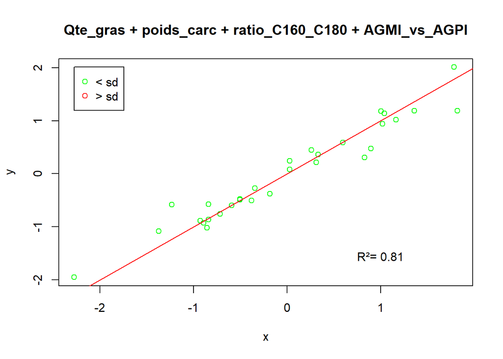

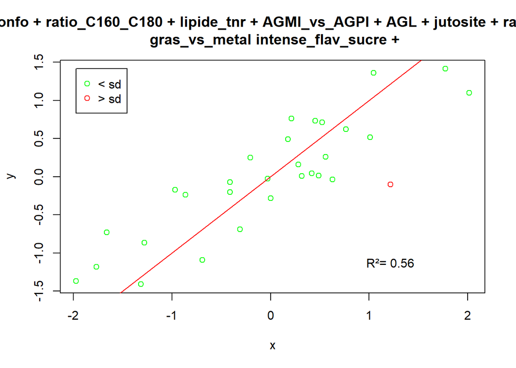

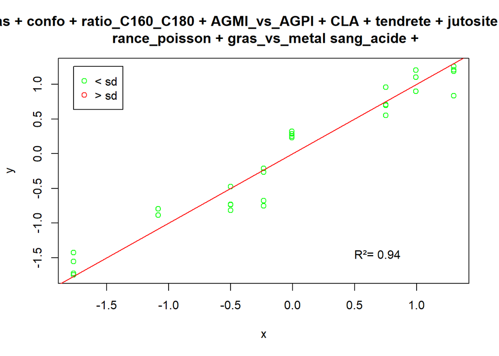

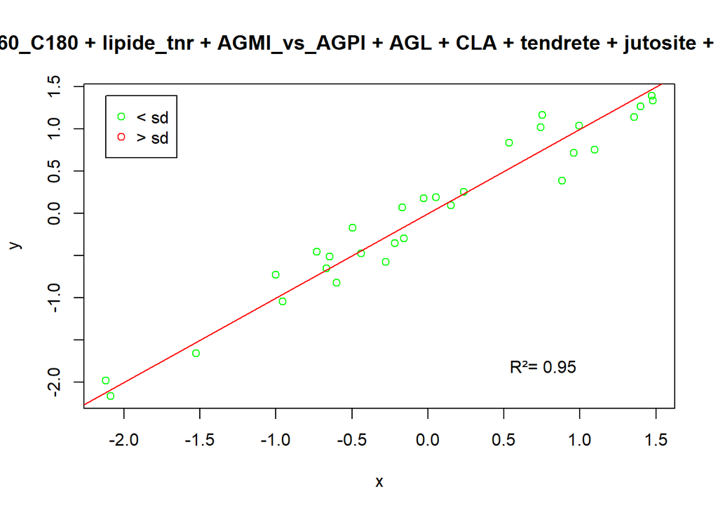

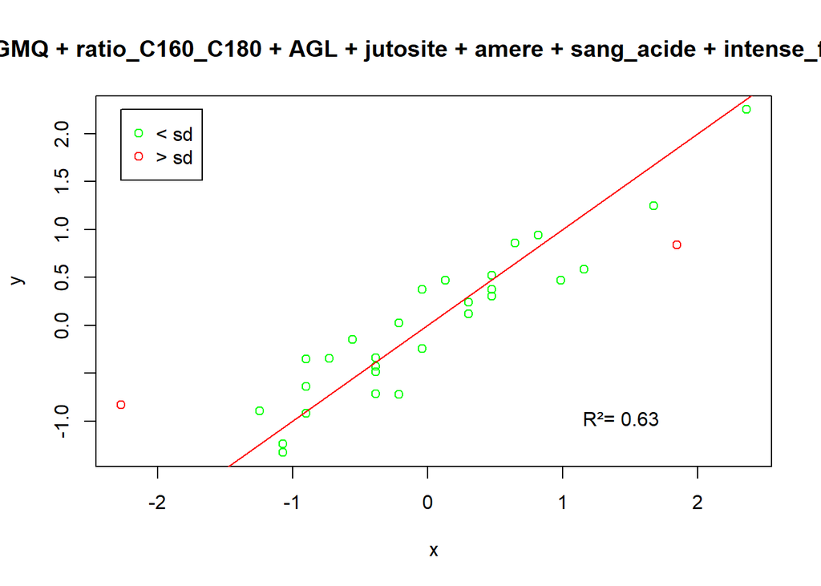

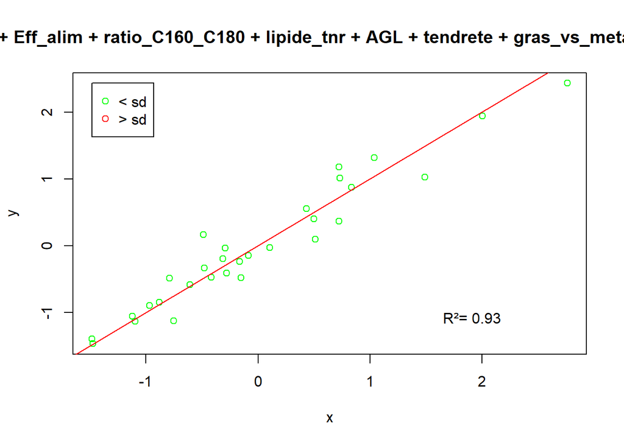

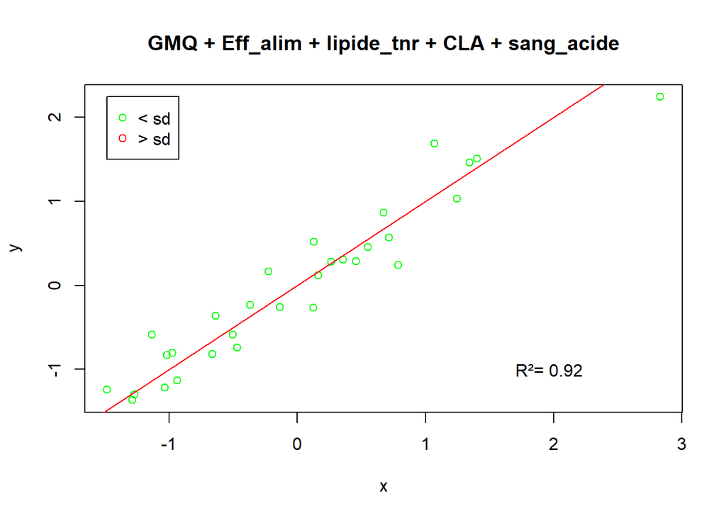

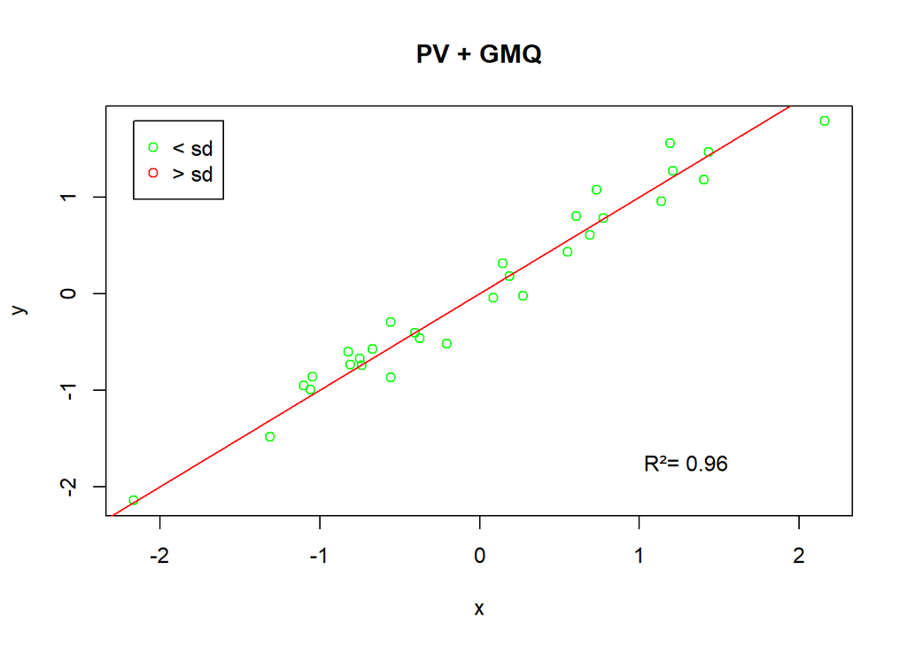

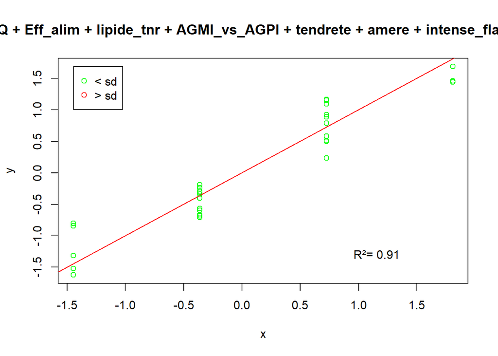

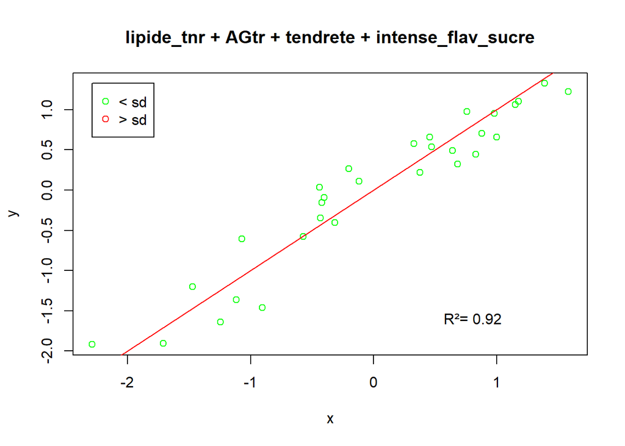

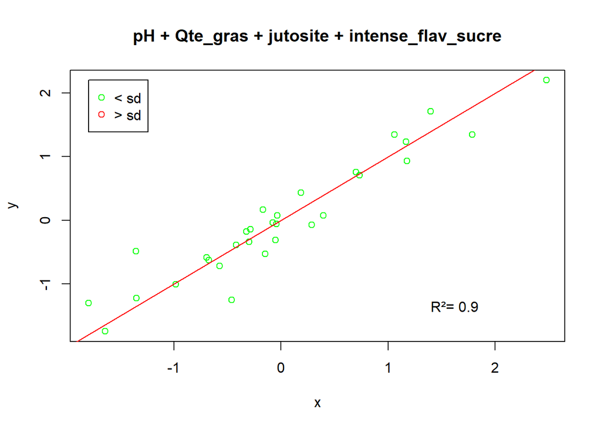

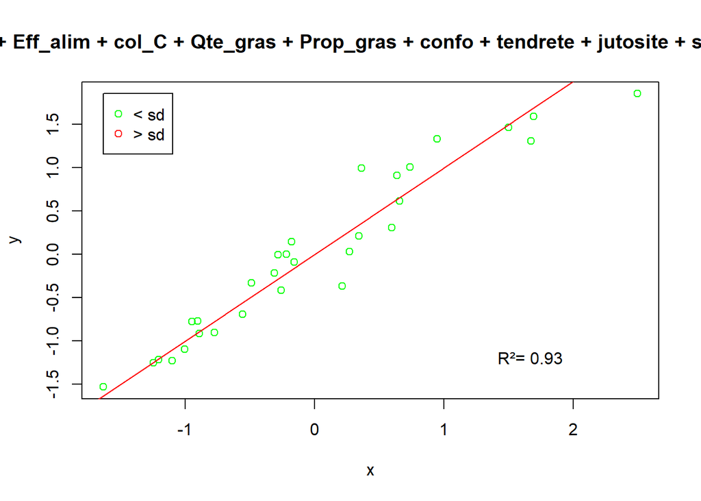

[12 more figures not shown]

```r
res <- as.data.frame(matrix(NA, ncol = 7, nrow = ncol(data)))
rownames(res) <- colnames(data)
colnames(res) <- c('R2', 'R2_cor', 'RMSE', 'RMSE_cor', 'R2Adj', 'R2Adj_cor', 'model')

for (i in 1:ncol(data)){
  qlt <- qlt_model(model = models[[i]])
  plot(qlt)
  for (j in 1:length(qlt$qlt)){
    res[i, j] <- qlt$qlt[[j]]
  }

  res[i, 7] <- class(models[[i]])
}
```

```r
# write.csv2(res, file='../plot/qtl_models_final_scale.csv', sep="\t")
```

```r
p <- ncol(data)
sensibilite <- as.data.frame(matrix(NA, ncol = p, nrow = p))
rownames(sensibilite) <- colnames(data)
colnames(sensibilite) <- colnames(data)
set.seed(123)

for (m in 1:p){
  col <- which(colnames(data) %in% models[[m]]$Xlabels)
  j <- 1
  ss <- sobol_sensitivity(model = models[[m]], order = 1, n = 10000, nboot = 300, seed = 123)

  for (i in col){
    sensibilite[m, i] <- round(ss$original[ j], 3)
    j <- j + 1
  }

}

sensibilite
```

```
##                       PV    GMQ Eff_alim  col_C    pH Qte_gras Prop_gras
## PV                    NA     NA       NA     NA    NA    0.043        NA
## GMQ                   NA     NA       NA  0.111 0.151    0.033        NA
## Eff_alim              NA     NA       NA  0.012 0.196       NA     0.086
## col_C              0.551     NA    0.017     NA    NA       NA        NA
## pH                 0.335  0.038       NA     NA    NA       NA        NA
## Qte_gras           0.449 -0.010   -0.015     NA    NA       NA        NA
## Prop_gras             NA  0.035    0.014     NA    NA       NA        NA
## poids_carc         0.971  0.009       NA     NA    NA       NA        NA
## confo                 NA  0.041    0.409     NA    NA       NA        NA
## col_lumi              NA     NA       NA     NA    NA       NA        NA
## ratio_C160_C180       NA     NA       NA     NA 0.395    0.156        NA
## lipide_tnr            NA  0.002   -0.012 -0.009    NA    0.257     0.694
## AGMI_vs_AGPI       0.026  0.008   -0.013 -0.016    NA       NA     0.861
## AGL                   NA     NA       NA  0.005 0.030    0.033    -0.001
## AGtr                  NA     NA    0.283  0.347    NA       NA     0.156
## n6_sur_n3          0.098     NA    0.196  0.219    NA       NA     0.422
## CLA                   NA     NA    0.192     NA    NA    0.576     0.105
## tendrete           0.149     NA       NA     NA    NA    0.553        NA
## jutosite           0.195  0.018    0.143  0.128 0.164    0.008        NA
## amere                 NA     NA       NA     NA 0.280    0.049        NA
## rance_poisson         NA     NA       NA     NA    NA       NA        NA
## gras_vs_metal         NA  0.173       NA  0.008 0.022    0.001        NA
## sang_acide            NA  0.024    0.281     NA    NA       NA     0.062
## intense_flav_sucre 0.063  0.140    0.004     NA    NA    0.085     0.482
##                    poids_carc  confo col_lumi ratio_C160_C180 lipide_tnr
## PV                      0.930     NA       NA          -0.010         NA
## GMQ                        NA  0.028       NA           0.075      0.032
## Eff_alim                   NA  0.196       NA          -0.003         NA
## col_C                      NA     NA       NA           0.112      0.001
## pH                         NA     NA       NA           0.116         NA
## Qte_gras                   NA     NA       NA           0.001      0.483
## Prop_gras                  NA     NA       NA              NA      0.911
## poids_carc                 NA     NA       NA              NA         NA
## confo                      NA     NA       NA              NA      0.111
## col_lumi                   NA     NA       NA              NA      0.811
## ratio_C160_C180            NA     NA       NA              NA         NA
## lipide_tnr                 NA -0.011       NA              NA         NA
## AGMI_vs_AGPI               NA -0.002       NA              NA         NA
## AGL                     0.047     NA    0.003              NA         NA
```

[output cut: 70 more lines]

```
## col_lumi                        0.118
## ratio_C160_C180                 0.130
## lipide_tnr                         NA
## AGMI_vs_AGPI                   -0.016
## AGL                             0.034
## AGtr                               NA
## n6_sur_n3                          NA
## CLA                                NA
## tendrete                           NA
## jutosite                           NA
## amere                              NA
## rance_poisson                      NA
## gras_vs_metal                      NA
## sang_acide                         NA
## intense_flav_sucre                 NA
```

```r
#check sum of the sensibilite by model
apply(as.matrix(sensibilite), MARGIN = 1, FUN = sum, na.rm = TRUE)
```

```
##                 PV                GMQ           Eff_alim
##              0.952              1.106              0.870
##              col_C                 pH           Qte_gras
##              0.898              0.884              0.856
##          Prop_gras         poids_carc              confo
##              1.003              0.980              0.928
##           col_lumi    ratio_C160_C180         lipide_tnr
##              0.961              0.926              0.882
##       AGMI_vs_AGPI                AGL               AGtr
##              0.826              0.949              0.915
##          n6_sur_n3                CLA           tendrete
##              1.044              0.922              0.885
##           jutosite              amere      rance_poisson
##              1.072              0.896              0.881
##      gras_vs_metal         sang_acide intense_flav_sucre
##              0.887              0.898              0.934
```

```r
# write.csv2(sensibilite, file='../plot/sensibilite_models_final_scale.csv', sep="\t")
```

Très long computationnellement, plusieurs jours selon la puissance de la machine

```r
# list_index <- list(EI = 1:3,
#                    QC = 4:10,
#                    QN = 11:17,
#                    QS = 18:24)
#
# n <- 5000
#
#
# sd_index <- apply(X = data[,list_index[[1]]], MARGIN = 2, FUN = sd)
# res <- simulation(data = data, n = n/4, models = models, index = list_index[[1]],
#                   borne = 2*sd_index , list_index = list_index, seed = 123)
# res$initiation <- names(list_index)[1]
#
# i <- 2
# for (index in list_index[-1]){
#
#   sd_index <- apply(X = data[, index], MARGIN = 2, FUN = sd)
#   res_interm <- simulation(data = data, n = n/4, models = models, index = index,
#                   borne = 2*sd_index , list_index = list_index, seed = 123)
#   res_interm$initiation <- names(list_index)[i]
#   res <- rbind(res, res_interm)
#   i <- i + 1
#
# }
#
# dim(res)
# res
```

```r
# write.csv2(res, file='../data/big_simulation4.csv', sep="\t")
```

```r
library(OptFilBov)

#import data
data <- as.matrix(read.csv('../data/big_simulation500.csv', header = T, sep = ';', dec = ',')[,-26])
initiation <- as.factor(as.vector(read.csv('../data/big_simulation500.csv', header = T, sep = ';', dec = ',')[,26]))
CDC <- read.csv('../data/cahier_des_charges3.csv', header = T, sep = ';', dec = ',')
CDC$objectif <- as.factor(CDC$objectif)
CDC
```

```
##    cluster seuil coef_agreg objectif
## 1      EI1  -1.5      0.330     <NA>
## 2      EI2  -1.5      0.330     <NA>
## 3      EI3   1.5     -0.330     <NA>
## 4      QC1  -1.5      0.100     <NA>
## 5      QC2    NA      0.000     <NA>
## 6      QC3   1.5     -0.200     <NA>
## 7      QC4   1.5     -0.200     <NA>
## 8      QC5  -1.5      0.150     <NA>
## 9      QC6  -1.5      0.200     <NA>
## 10     QC7  -1.5      0.150     <NA>
## 11     QN1    NA     -0.150        1
## 12     QN2    NA     -0.150        1
## 13     QN3    NA      0.250        1
## 14     QN4    NA      0.050        1
## 15     QN5    NA      0.050        1
## 16     QN6    NA     -0.250        1
## 17     QN7    NA      0.100        1
## 18     QS1    NA      0.425        2
## 19     QS2    NA      0.150        2
## 20     QS3    NA     -0.025        2
## 21     QS4    NA     -0.125        2
## 22     QS5    NA     -0.050        2
## 23     QS6    NA     -0.050        2
## 24     QS7    NA      0.175        2
```

```r
objectifs <- list()
for (k in levels(CDC$objectif)){

  objectifs[[k]]$index <- which(CDC$objectif == k)
  objectifs[[k]]$w <- CDC$coef_agreg[which(CDC$objectif == k)]
  names(objectifs)[as.numeric(k)] <- paste(unlist(strsplit(as.character(CDC$cluster[which(CDC$objectif == k)][1]), split = ''))[-3], collapse = '')

}


constraint <- list(seuil_plus = CDC$seuil[which(! is.na(CDC$seuil) & CDC$seuil > 0)],
                   seuil_minus = CDC$seuil[which(! is.na(CDC$seuil) & CDC$seuil < 0)],
                   index_plus = which(! is.na(CDC$seuil) & CDC$seuil > 0),
                   index_minus = which(! is.na(CDC$seuil) & CDC$seuil < 0))



res <- bovCDC(X = data[,-1],
              objectifs = objectifs,
              constraint = constraint,
              scale = TRUE)

delete_by_threshold <- which(!res$constraint_respected)
if (length(delete_by_threshold)>0) res <- res[-delete_by_threshold, 1:2] else res<-res[,1:2]
```

A cette étape on vient de supprimer 0 individus qui ne respectait pas les conditions. A remarquer que c’est faible mais aussi que le seuil est en faite un plafond (donc l’inverse de ce que l’on recherche) pour les indicateurs qui sont optimiser lorsqu’il sont faibles.

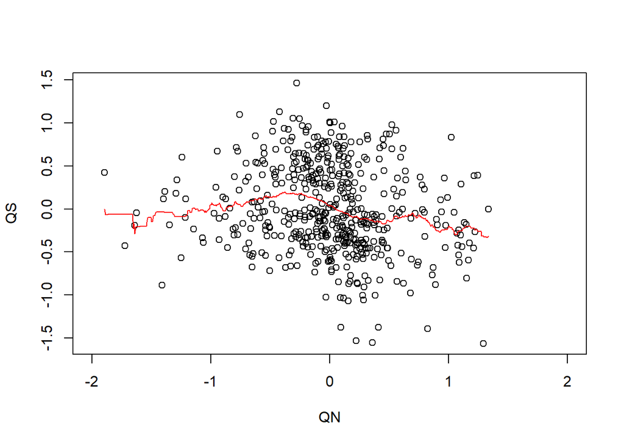

```r
plot(res, xlim=c(-2,2))
lines(ksmooth(x = res[,1], y = res[,2]), col = 'red')
```

```r
cor(res)
```

```
##            QN         QS
## QN  1.0000000 -0.1739553
## QS -0.1739553  1.0000000
```

```r
cor.test(res[,1], res[,2])
```

```
##
##  Pearson's product-moment correlation
##
## data:  res[, 1] and res[, 2]
## t = -3.9421, df = 498, p-value = 9.235e-05
## alternative hypothesis: true correlation is not equal to 0
## 95 percent confidence interval:
##  -0.25771462 -0.08760097
## sample estimates:
##        cor
## -0.1739553
```

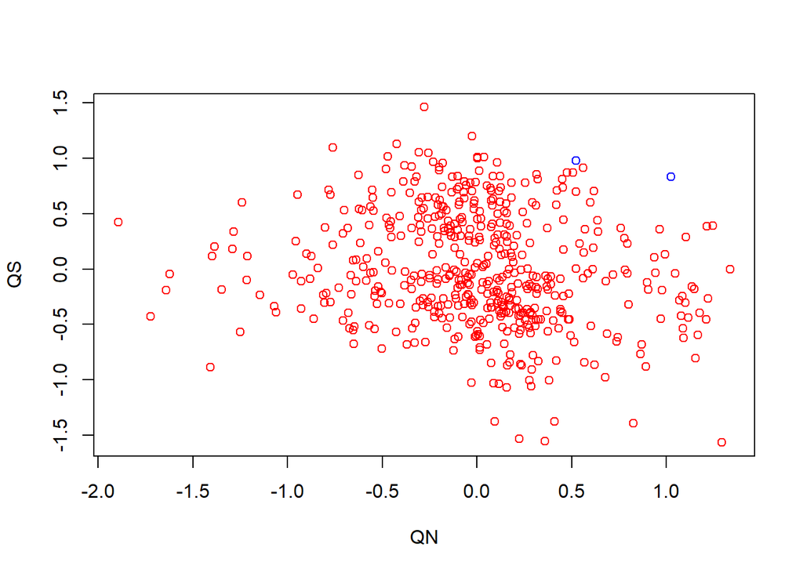

```r
# dev.off()

X_scale <- scale(data)
X_decision <- pareto_finding (X = X_scale, Y = res, method = 'target', target = c(1.5,1.5), n = 2, plot = TRUE)
```

```r
bon <- X_decision$Y_index
```

Par rapport aux derniers resultats, on remarque que QS et QN sont lègerement negativement correles. Bon signe pour notre étude même si c’est pas flagrant et que les points du milieu sont un peu bizarres (cf l’explication plus bas)

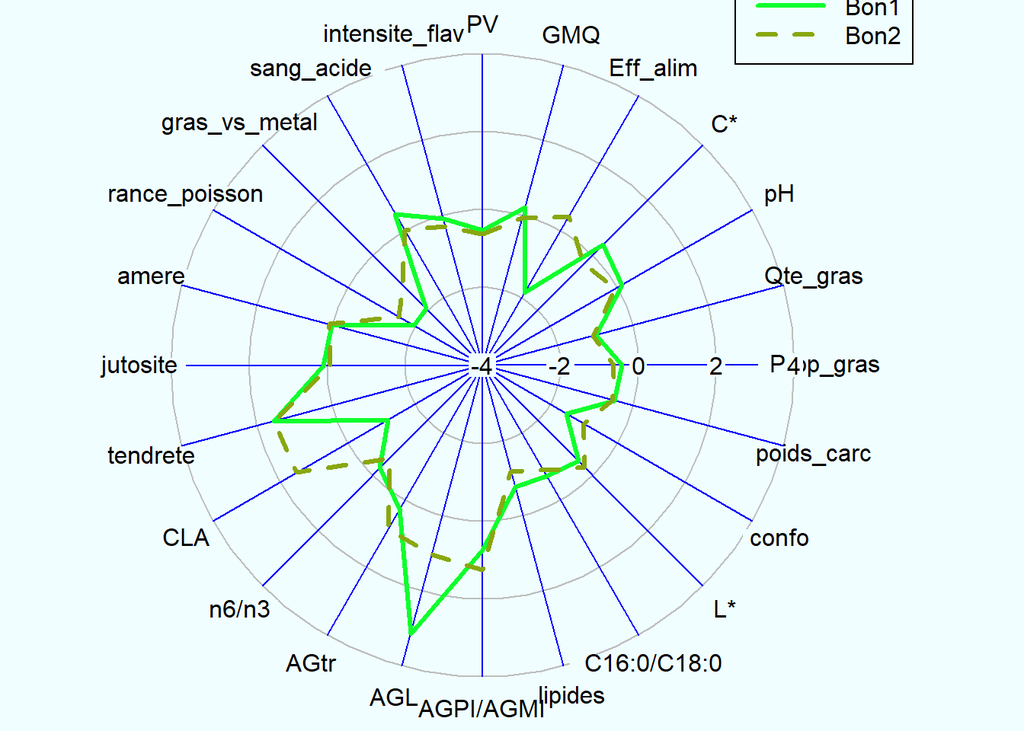

```r
color <- c(rgb(15,255,45,maxColorValue=255), rgb(137,167,16,maxColorValue=255))
cow <- as.matrix(as.data.frame(X_decision$X)[-1])
class(cow) <- 'cow'
colnames(cow)[4] <- 'C*'
colnames(cow)[10] <- 'L*'
colnames(cow)[13] <- 'AGPI/AGMI'
colnames(cow)[16] <- 'n6/n3'
colnames(cow)[11] <- 'C16:0/C18:0'
colnames(cow)[12] <- 'lipides'
colnames(cow)[24] <- 'intensite_flav'

plot(cow, choice = 'radar_diag',  radial.lim = c(-4,4), color=color, cex=1, legend_label = c("Bon1", "Bon2"),
     lty=c(1,2), x_legend=6.5, y_legend=10, bg_par=rgb(240,254,255, maxColorValue=255), seg.len=3)
```

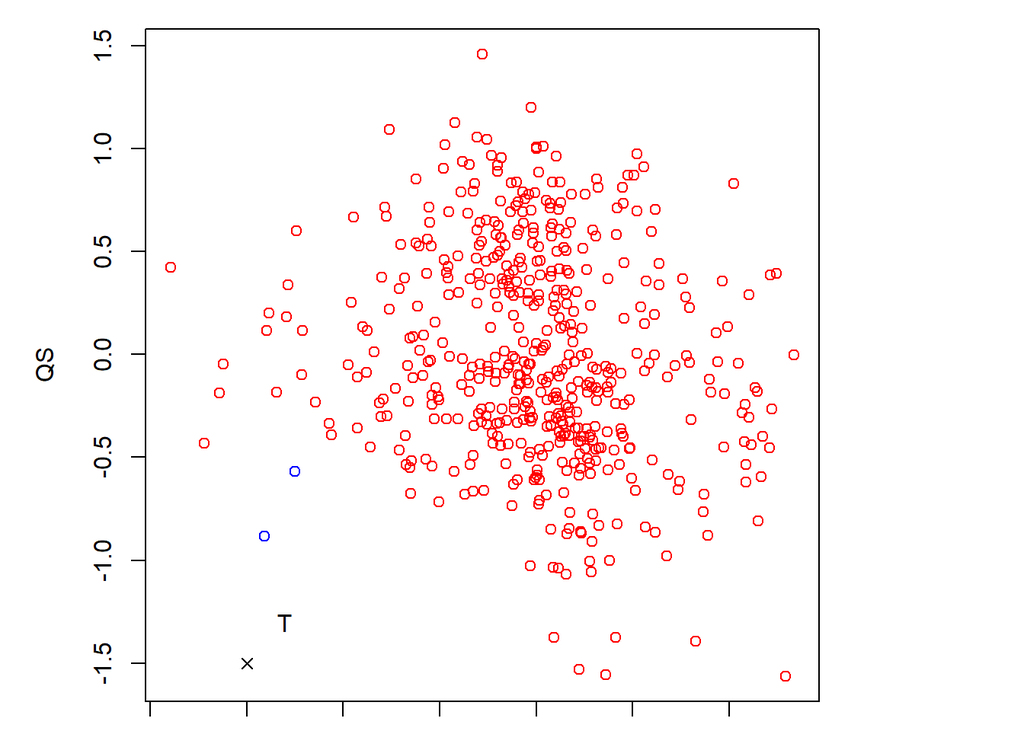

```r
# dev.copy(svg,'../plot/bon_profil.svg')
# dev.off()
# dev.copy(png,'../plot/bon_profil3R.png')
# dev.off()

X_decision <- pareto_finding (X = X_scale, Y = res, method = 'target', target = c(-1.5,-1.5), n = 2, plot = TRUE)
```

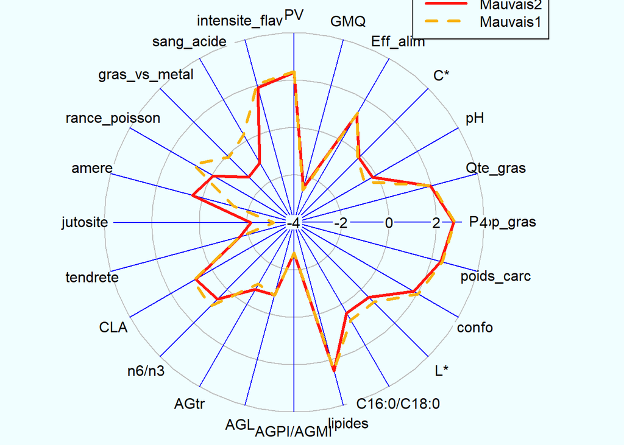

```r
mauvais <- X_decision$Y_index


color <- c(rgb(255,21,15,maxColorValue=255), rgb(248,179,16,maxColorValue=255))
cow <- as.matrix(as.data.frame(X_decision$X)[-1])
class(cow) <- 'cow'
colnames(cow)[4] <- 'C*'
colnames(cow)[10] <- 'L*'
colnames(cow)[13] <- 'AGPI/AGMI'
colnames(cow)[16] <- 'n6/n3'
colnames(cow)[11] <- 'C16:0/C18:0'
colnames(cow)[12] <- 'lipides'
colnames(cow)[24] <- 'intensite_flav'

plot(cow, choice = 'radar_diag',  radial.lim = c(-4,4), color=color, cex=1, legend_label = c("Mauvais2", "Mauvais1"),lty=c(1,2),
     x_legend=5, y_legend=10, bg_par=rgb(240,254,255, maxColorValue=255), seg.len=3)
```

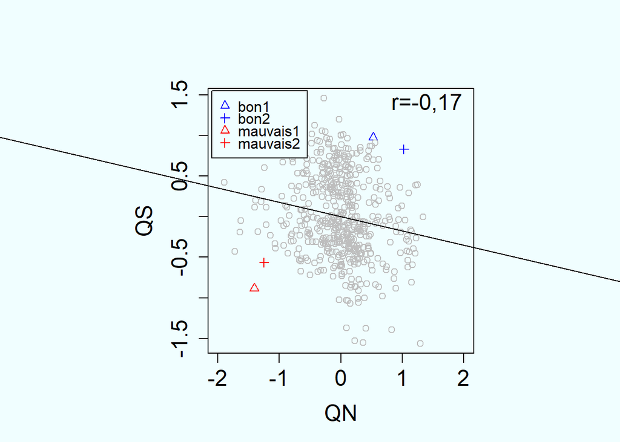

```r
# dev.copy(svg,'../plot/mauvais_profil.svg')
# dev.off()
# dev.copy(png,'../plot/mauvais_profil3R.png')
# dev.off()


a <- rep(1, nrow(res))
a[bon] <- 2
a[mauvais] <- 3
a <- as.factor(a)

pch <- rep(1, nrow(res))
pch[c(bon[1], mauvais[2])] <- 2
pch[c(bon[2], mauvais[1])] <- 3

par(mai=c(1,0.8,1,0.1))
par(bg=rgb(240,254,255, maxColorValue=255))
plot(res, col = c('grey', 'blue', 'red')[a], pch=pch, xlim=c(-2,2), cex.axis=1.5, cex.lab=1.5)
legend(x=-2.1, y=1.55, legend = c('bon1', 'bon2', 'mauvais1', 'mauvais2'), pch = (2:3)[c(1,2,1,2)], col = c('blue', 'red')[c(1,1,2,2)], cex=1, y.intersp = 0.7)
abline(lm(res[,2]~res[,1]))
text(x=1.4, y=1.4,labels = 'r=-0,17', cex=1.5)
```

```r
# dev.copy(png, '../plot/compromis.png')
# dev.off()
```

Ici on retrouve le profil de nos meilleurs compromis.